# Planar data classification with one hidden layer

Welcome to your next programming assignment. It's time to build your first neural network, which will have a hidden layer. You will see a big difference between this model and the one you implemented using logistic regression.

**You will learn how to:**

- Implement a 2-class classification neural network with a single hidden layer
- Use units with a non-linear activation function, such as tanh
- Compute the cross entropy loss
- Implement forward and backward propagation

# Note:

I removed the unit tests and markdown cells to make the notebook smaller

```python
# Package imports
import numpy as np
import matplotlib.pyplot as plt
from testCases import *
import sklearn
import sklearn.datasets
import sklearn.linear_model
from planar_utils import plot_decision_boundary, sigmoid, load_planar_dataset, load_extra_datasets
import warnings
warnings.filterwarnings('ignore')

%matplotlib inline

np.random.seed(1) # set a seed so that the results are consistent
```

```python
X, Y = load_planar_dataset()
```

```python
# GRADED FUNCTION: layer_sizes

def layer_sizes(X, Y):
    """
    Arguments:
    X -- input dataset of shape (input size, number of examples)
    Y -- labels of shape (output size, number of examples)

    Returns:
    n_x -- the size of the input layer
    n_h -- the size of the hidden layer
    n_y -- the size of the output layer
    """
    ### START CODE HERE ### (≈ 3 lines of code)
    n_x = X.shape[0]
    n_h = 4
    n_y = Y.shape[0]
    ### END CODE HERE ###
    return (n_x, n_h, n_y)
```

```python
# GRADED FUNCTION: initialize_parameters

def initialize_parameters(n_x, n_h, n_y):
    """
    Argument:
    n_x -- size of the input layer
    n_h -- size of the hidden layer
    n_y -- size of the output layer

    Returns:
    params -- python dictionary containing your parameters:
                    W1 -- weight matrix of shape (n_h, n_x)
                    b1 -- bias vector of shape (n_h, 1)
                    W2 -- weight matrix of shape (n_y, n_h)
                    b2 -- bias vector of shape (n_y, 1)
    """

    np.random.seed(2) # we set up a seed so that your output matches ours although the initialization is random.

    ### START CODE HERE ### (≈ 4 lines of code)
    W1 = np.random.randn(n_h, n_x) * 0.01
    b1 = np.zeros((n_h, 1))
    W2 = np.random.randn(n_y, n_h) * 0.01
    b2 = np.zeros((n_y, 1))
    ### END CODE HERE ###

    assert (W1.shape == (n_h, n_x))
    assert (b1.shape == (n_h, 1))
    assert (W2.shape == (n_y, n_h))
    assert (b2.shape == (n_y, 1))

    parameters = {"W1": W1,
                  "b1": b1,
                  "W2": W2,
                  "b2": b2}

    return parameters
```

```python
# GRADED FUNCTION: forward_propagation

def forward_propagation(X, parameters):
    """
    Argument:
    X -- input data of size (n_x, m)
    parameters -- python dictionary containing your parameters (output of initialization function)

    Returns:
    A2 -- The sigmoid output of the second activation
    cache -- a dictionary containing "Z1", "A1", "Z2" and "A2"
    """
    # Retrieve each parameter from the dictionary "parameters"
    ### START CODE HERE ### (≈ 4 lines of code)
    W1 = parameters["W1"]
    b1 = parameters["b1"]
    W2 = parameters["W2"]
    b2 = parameters["b2"]
    ### END CODE HERE ###

    # Implement Forward Propagation to calculate A2 (probabilities)
    ### START CODE HERE ### (≈ 4 lines of code)
    Z1 = W1@X+b1
    A1 = np.tanh(Z1)
    Z2 = W2@A1+b2
    A2 = sigmoid(Z2)
    ### END CODE HERE ###

    assert(A2.shape == (1, X.shape[1]))

    cache = {"Z1": Z1,
             "A1": A1,
             "Z2": Z2,
             "A2": A2}

    return A2, cache
```

```python
# GRADED FUNCTION: compute_cost

def compute_cost(A2, Y, parameters):
    """
    Computes the cross-entropy cost given in equation (13)

    Arguments:
    A2 -- The sigmoid output of the second activation, of shape (1, number of examples)
    Y -- "true" labels vector of shape (1, number of examples)
    parameters -- python dictionary containing your parameters W1, b1, W2 and b2

    Returns:
    cost -- cross-entropy cost given equation (13)
    """

    m = Y.shape[1] # number of example

    # Retrieve W1 and W2 from parameters
    ### START CODE HERE ### (≈ 2 lines of code)
    W1 = parameters["W1"]
    W2 = parameters["W2"]
    ### END CODE HERE ###

    # Compute the cross-entropy cost
    ### START CODE HERE ### (≈ 2 lines of code)
    cost = - np.mean((Y*np.log(A2))+((1-Y)*(np.log(1-A2))))
    ### END CODE HERE ###

    cost = np.squeeze(cost)     # makes sure cost is the dimension we expect.
                                # E.g., turns [[17]] into 17
    assert(isinstance(cost, float))

    return cost
```

```python
# GRADED FUNCTION: backward_propagation

def backward_propagation(parameters, cache, X, Y):
    """
    Implement the backward propagation using the instructions above.

    Arguments:
    parameters -- python dictionary containing our parameters
    cache -- a dictionary containing "Z1", "A1", "Z2" and "A2".
    X -- input data of shape (2, number of examples)
    Y -- "true" labels vector of shape (1, number of examples)

    Returns:
    grads -- python dictionary containing your gradients with respect to different parameters
    """
    m = X.shape[1]

    # First, retrieve W1 and W2 from the dictionary "parameters".
    ### START CODE HERE ### (≈ 2 lines of code)
    W1 = parameters["W1"]
    W2 = parameters["W2"]
    ### END CODE HERE ###

    # Retrieve also A1 and A2 from dictionary "cache".
    ### START CODE HERE ### (≈ 2 lines of code)
    A1 = cache['A1']
    A2 = cache['A2']
    ### END CODE HERE ###

    # Backward propagation: calculate dW1, db1, dW2, db2.
    ### START CODE HERE ### (≈ 6 lines of code, corresponding to 6 equations on slide above)
    dZ2 = A2 - Y
    dW2 = (dZ2@A1.T)/m
    db2 = (np.sum(dZ2, axis=1, keepdims=True))/m
    dZ1 = W2.T@dZ2 * (1 - np.power(A1, 2))
    dW1 = (dZ1@X.T)/m
    db1 = (np.sum(dZ1, axis=1, keepdims=True))/m
    ### END CODE HERE ###

    grads = {"dW1": dW1,
             "db1": db1,
             "dW2": dW2,
             "db2": db2}

    return grads
```

```python
# GRADED FUNCTION: update_parameters

def update_parameters(parameters, grads, learning_rate=1.2):
    """
    Updates parameters using the gradient descent update rule given above

    Arguments:
    parameters -- python dictionary containing your parameters
    grads -- python dictionary containing your gradients

    Returns:
    parameters -- python dictionary containing your updated parameters
    """
    # Retrieve each parameter from the dictionary "parameters"
    ### START CODE HERE ### (≈ 4 lines of code)
    W1 = parameters["W1"]
    W2 = parameters["W2"]
    b1 = parameters["b1"]
    b2 = parameters["b2"]
    ### END CODE HERE ###

    # Retrieve each gradient from the dictionary "grads"
    ### START CODE HERE ### (≈ 4 lines of code)
    dW1 = grads['dW1']
    db1 = grads['db1']
    dW2 = grads['dW2']
    db2 = grads['db2']
    ## END CODE HERE ###

    # Update rule for each parameter
    ### START CODE HERE ### (≈ 4 lines of code)
    def update(x,dx):
        return(x-(learning_rate*dx))
    W1 = update(W1,dW1)
    b1 = update(b1,db1)
    W2 = update(W2,dW2)
    b2 = update(b2,db2)
    ### END CODE HERE ###

    parameters = {"W1": W1,
                  "b1": b1,
                  "W2": W2,
                  "b2": b2}

    return parameters
```

```python
# GRADED FUNCTION: nn_model

def nn_model(X, Y, n_h, num_iterations=10000, print_cost=False):
    """
    Arguments:
    X -- dataset of shape (2, number of examples)
    Y -- labels of shape (1, number of examples)
    n_h -- size of the hidden layer
    num_iterations -- Number of iterations in gradient descent loop
    print_cost -- if True, print the cost every 1000 iterations

    Returns:
    parameters -- parameters learnt by the model. They can then be used to predict.
    """

    np.random.seed(3)
    n_x = layer_sizes(X, Y)[0]
    n_y = layer_sizes(X, Y)[2]

    # Initialize parameters, then retrieve W1, b1, W2, b2. Inputs: "n_x, n_h, n_y". Outputs = "W1, b1, W2, b2, parameters".
    ### START CODE HERE ### (≈ 5 lines of code)
    parameters = initialize_parameters(n_x, n_h, n_y)
    W1 = parameters["W1"]
    b1 = parameters["b1"]
    W2 = parameters["W2"]
    b2 = parameters["b2"]
    ### END CODE HERE ###

    # Loop (gradient descent)

    for i in range(0, num_iterations):

        ### START CODE HERE ### (≈ 4 lines of code)
        # Forward propagation. Inputs: "X, parameters". Outputs: "A2, cache".
        A2, cache = forward_propagation(X, parameters)

        # Cost function. Inputs: "A2, Y, parameters". Outputs: "cost".
        cost = compute_cost(A2, Y, parameters)

        # Backpropagation. Inputs: "parameters, cache, X, Y". Outputs: "grads".
        grads = backward_propagation(parameters, cache, X, Y)

        # Gradient descent parameter update. Inputs: "parameters, grads". Outputs: "parameters".
        parameters = update_parameters(parameters, grads)

        ### END CODE HERE ###

        # Print the cost every 1000 iterations
        if print_cost and i % 1000 == 0:
            print ("Cost after iteration %i: %f" % (i, cost))

    return parameters
```

```python
# GRADED FUNCTION: predict

def predict(parameters, X):
    """
    Using the learned parameters, predicts a class for each example in X

    Arguments:
    parameters -- python dictionary containing your parameters
    X -- input data of size (n_x, m)

    Returns
    predictions -- vector of predictions of our model (red: 0 / blue: 1)
    """

    # Computes probabilities using forward propagation, and classifies to 0/1 using 0.5 as the threshold.
    ### START CODE HERE ### (≈ 2 lines of code)
    A2, cache = forward_propagation(X, parameters)
    predictions = np.where(A2>0.5, 1, 0)
    ### END CODE HERE ###

    return predictions
```

```
Cost after iteration 0: 0.693048
Cost after iteration 1000: 0.288083
Cost after iteration 2000: 0.254385
Cost after iteration 3000: 0.233864
Cost after iteration 4000: 0.226792
Cost after iteration 5000: 0.222644
Cost after iteration 6000: 0.219731
Cost after iteration 7000: 0.217504
Cost after iteration 8000: 0.219577
Cost after iteration 9000: 0.218591
```

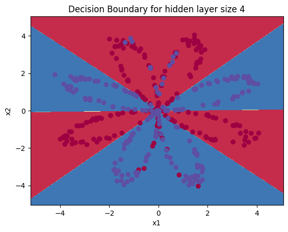

```python
# Build a model with a n_h-dimensional hidden layer
parameters = nn_model(X, Y, n_h = 4, num_iterations=10000, print_cost=True)

# Plot the decision boundary
plot_decision_boundary(lambda x: predict(parameters, x.T), X, Y)
plt.title("Decision Boundary for hidden layer size " + str(4))
```

```python
# Print accuracy
predictions = predict(parameters, X)
print ('Accuracy: %d' % float((np.dot(Y, predictions.T) + np.dot(1 - Y, 1 - predictions.T)) / float(Y.size) * 100) + '%')
```

```
Accuracy: 90%
```

# Step 1:

Develop code with a for-loop to explore a range of n_h values {1, 2, 3, 4, 5, 20, 50}.

# Step 2:

For each n_h value, run your notebook from Week2-HW2 and classify the dataset. Extract the tuned parameters of the model.

```python
n_h_vals = [1, 2, 3, 4, 5, 20, 50]
results = {
}

for n_h in n_h_vals:
    print(f'Evalating hidden Layer of size {n_h}')
    results[f'{n_h}'] = nn_model(X, Y, n_h = n_h, num_iterations=10000, print_cost=False)
```

```
Evalating hidden Layer of size 1
Evalating hidden Layer of size 2
Evalating hidden Layer of size 3
Evalating hidden Layer of size 4
Evalating hidden Layer of size 5
Evalating hidden Layer of size 20
Evalating hidden Layer of size 50
```

# Step 3:

Visualize the solution by plotting the decision boundary overlaid on the data points.

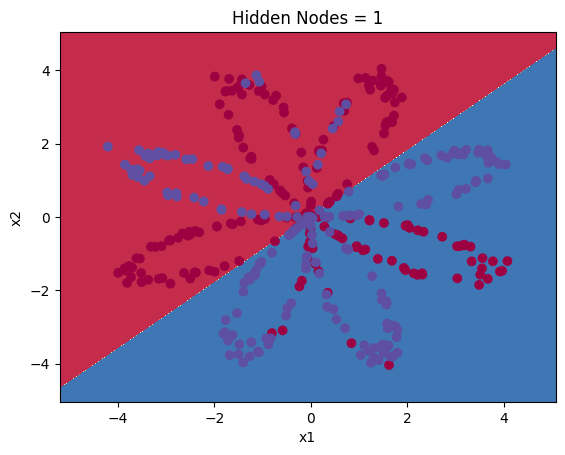

```python
plot_decision_boundary(lambda x: predict(results[f'1'], x.T), X, Y, title='Hidden Nodes = 1')
```

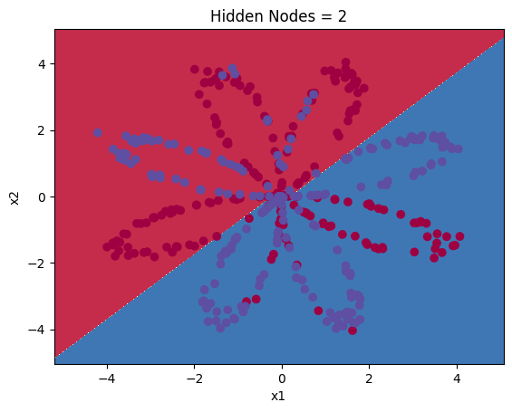

```python
plot_decision_boundary(lambda x: predict(results[f'2'], x.T), X, Y, title='Hidden Nodes = 2')
```

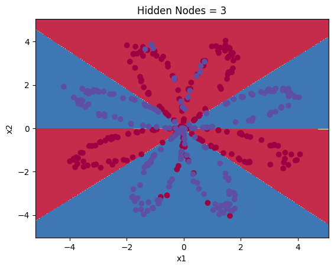

```python
plot_decision_boundary(lambda x: predict(results[f'3'], x.T), X, Y, title='Hidden Nodes = 3')
```

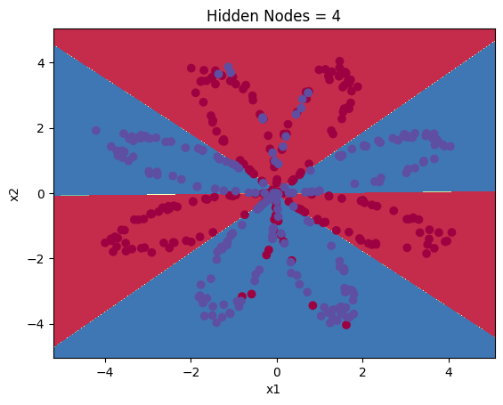

```python
plot_decision_boundary(lambda x: predict(results[f'4'], x.T), X, Y, title='Hidden Nodes = 4')
```

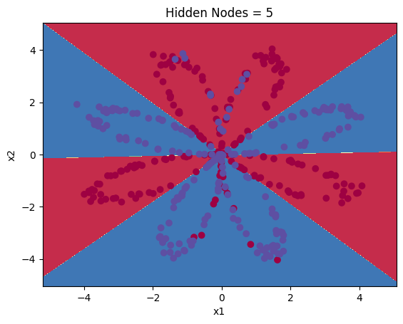

```python
plot_decision_boundary(lambda x: predict(results[f'5'], x.T), X, Y, title='Hidden Nodes = 5')
```

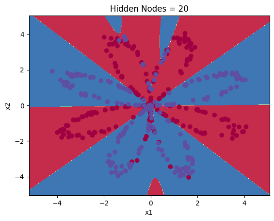

```python
plot_decision_boundary(lambda x: predict(results[f'20'], x.T), X, Y, title='Hidden Nodes = 20')
```

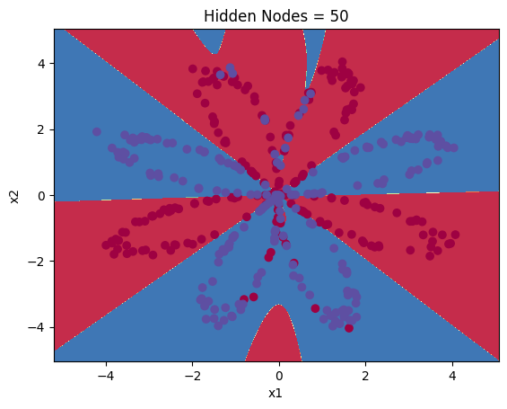

```python
plot_decision_boundary(lambda x: predict(results[f'50'], x.T), X, Y, title='Hidden Nodes = 50')
```

# Step 4:

Evaluate the accuracy of the prediction to pick the n_h value that returns the highest accuracy.

```python
for n_h in n_h_vals:
    predictions = predict(results[f'{n_h}'], X)
    print (f'Accuracy with {n_h} nodes: {float((np.dot(Y, predictions.T) + np.dot(1 - Y, 1 - predictions.T)) / float(Y.size) * 100):.02f}%')
```

```
Accuracy with 1 nodes: 67.50%
Accuracy with 2 nodes: 67.25%
Accuracy with 3 nodes: 91.00%
Accuracy with 4 nodes: 90.75%
Accuracy with 5 nodes: 91.50%
Accuracy with 20 nodes: 91.25%
Accuracy with 50 nodes: 92.25%
```

We see that accuracy is highest with 50 nodes in the hidden layer, but only by a small margin of about 0.75%. Using just 3 nodes is enough to get 91% accuracy.

# Step 5:

Re-run the training using tanh instead of the sigmoid function for the best n_h value. You will have to code up the tanh function in-place of the sigmoid function. Report the difference in timing.

# NOTE:

We're aleady using tanh for the hidden layer, so the only place to add tanh is in the output layer. This seems wrong because tanh outputs the range (-1,1) which cannot be interpreted as probabilities. This means that the cross entropy loss function won't work by default. So, I'm confused on why we would use tanh in the output layer for a classification problem.

Regardless, to ensure that the outputs are still probabilities, I rescale the tanh function after calculating and continue to use cross entropy loss.

```python
def forward_propagation_tanh(X, parameters):
    """
    Argument:
    X -- input data of size (n_x, m)
    parameters -- python dictionary containing your parameters (output of initialization function)

    Returns:
    A2 -- The sigmoid output of the second activation
    cache -- a dictionary containing "Z1", "A1", "Z2" and "A2"
    """
    # Retrieve each parameter from the dictionary "parameters"
    W1 = parameters["W1"]
    b1 = parameters["b1"]
    W2 = parameters["W2"]
    b2 = parameters["b2"]

    # Implement Forward Propagation to calculate A2 (probabilities)
    Z1 = W1@X+b1
    A1 = np.tanh(Z1)
    Z2 = W2@A1+b2
    #A2 = sigmoid(Z2)
    A2 = (np.tanh(Z2)+1)/2

    assert(A2.shape == (1, X.shape[1]))

    cache = {"Z1": Z1,
             "A1": A1,
             "Z2": Z2,
             "A2": A2}

    return A2, cache
```

```python
def backward_propagation_tanh(parameters, cache, X, Y):
    """
    Implement the backward propagation using the instructions above.

    Arguments:
    parameters -- python dictionary containing our parameters
    cache -- a dictionary containing "Z1", "A1", "Z2" and "A2".
    X -- input data of shape (2, number of examples)
    Y -- "true" labels vector of shape (1, number of examples)

    Returns:
    grads -- python dictionary containing your gradients with respect to different parameters
    """
    m = X.shape[1]

    # First, retrieve W1 and W2 from the dictionary "parameters".
    W1 = parameters["W1"]
    W2 = parameters["W2"]

    # Retrieve also A1 and A2 from dictionary "cache".
    A1 = cache['A1']
    A2 = cache['A2']

    # Backward propagation: calculate dW1, db1, dW2, db2.
    #dZ2 = A2 - Y
    dZ2 = 2 * (A2 - Y)
    dW2 = (dZ2@A1.T)/m
    db2 = (np.sum(dZ2, axis=1, keepdims=True))/m
    dZ1 = W2.T@dZ2 * (1 - np.power(A1, 2))
    dW1 = (dZ1@X.T)/m
    db1 = (np.sum(dZ1, axis=1, keepdims=True))/m
    ### END CODE HERE ###

    grads = {"dW1": dW1,
             "db1": db1,
             "dW2": dW2,
             "db2": db2}

    return grads
```

```python
def nn_model_tanh(X, Y, n_h, num_iterations=10000, print_cost=False):
    """
    Arguments:
    X -- dataset of shape (2, number of examples)
    Y -- labels of shape (1, number of examples)
    n_h -- size of the hidden layer
    num_iterations -- Number of iterations in gradient descent loop
    print_cost -- if True, print the cost every 1000 iterations

    Returns:
    parameters -- parameters learnt by the model. They can then be used to predict.
    """

    np.random.seed(3)
    n_x = layer_sizes(X, Y)[0]
    n_y = layer_sizes(X, Y)[2]

    # Initialize parameters, then retrieve W1, b1, W2, b2. Inputs: "n_x, n_h, n_y". Outputs = "W1, b1, W2, b2, parameters".
    parameters = initialize_parameters(n_x, n_h, n_y)
    W1 = parameters["W1"]
    b1 = parameters["b1"]
    W2 = parameters["W2"]
    b2 = parameters["b2"]

    # Loop (gradient descent)
    for i in range(0, num_iterations):

        # Forward propagation. Inputs: "X, parameters". Outputs: "A2, cache".
        A2, cache = forward_propagation_tanh(X, parameters)

        # Cost function. Inputs: "A2, Y, parameters". Outputs: "cost".
        cost = compute_cost(A2, Y, parameters)

        # Backpropagation. Inputs: "parameters, cache, X, Y". Outputs: "grads".
        grads = backward_propagation_tanh(parameters, cache, X, Y)

        # Gradient descent parameter update. Inputs: "parameters, grads". Outputs: "parameters".
        #parameters = update_parameters(parameters, grads)
        parameters = update_parameters(parameters, grads, learning_rate=0.6) # halved learning rate to 0.6 because of steeper gradients

        # Print the cost every 1000 iterations
        if print_cost and i % 1000 == 0:
            print ("Cost after iteration %i: %f" % (i, cost))

    return parameters
```

```python
n_h_vals = [1, 2, 3, 4, 5, 20, 50]
results = {
}

for n_h in n_h_vals:
    results[f'{n_h}'] = nn_model_tanh(X, Y, n_h = n_h, num_iterations=10000, print_cost=False)
    predictions = predict(results[f'{n_h}'], X)
    print (f'Accuracy with {n_h} nodes: {float((np.dot(Y, predictions.T) + np.dot(1 - Y, 1 - predictions.T)) / float(Y.size) * 100):.02f}%')
```

```
Accuracy with 1 nodes: 67.50%
Accuracy with 2 nodes: 67.25%
Accuracy with 3 nodes: 90.25%
Accuracy with 4 nodes: 91.25%
Accuracy with 5 nodes: 90.75%
Accuracy with 20 nodes: 91.50%
Accuracy with 50 nodes: 90.75%
```

Results are slightly different using tanh, but generally tell the same story that anything >= 3 nodes is sufficient for this problem.

```python
# Timing using timeit
import timeit
n = 100

time_sigmoid = timeit.timeit('nn_model(X, Y, n_h = 2, num_iterations=1000, print_cost=False)', globals=globals(), number=n)
time_tanh = timeit.timeit('nn_model_tanh(X, Y, n_h = 2, num_iterations=1000, print_cost=False)', globals=globals(), number=n)

print(f'Time using sigmoid: {time_sigmoid/n*1000:.1f} ms')
print(f'Time using tanh: {time_tanh/n*1000:.1f} ms')
print(f'Speedup using sigmoid: {(time_tanh-time_sigmoid)/n*1000:.2f} ms, or {(time_tanh-time_sigmoid)/time_tanh:.2f}% faster.')
```

```
Time using sigmoid: 91.5 ms
Time using tanh: 95.4 ms
Speedup using sigmoid: 3.95 ms, or 0.04% faster.
```

My sigmoid implementation is a little bit faster, on average.